# SCATT - Data analysis

SCATT (Stoichiometric Combinatorial Assembly on Transient Template) is an accessible strategy for constructing mutagenic libraries. Inspired by previous template-mediated assembly methods, SCATT allows the creation of user-tailored libraries via a simple experimental pipeline while tightly controlling the average number of mutations.

This notebook contains the analysis of our data.

# 1 C-domain of Bst.NBI

Load data and define relevant variables

Load sequences

We explored some statistics of the libraries.

How many sequences have the wrong length, meaning have InDels?

```
## # A tibble: 4 × 4
## # Groups:   experiment [4]
##   experiment right wrong percentage_wrong
##        <int> <int> <int>            <dbl>
## 1          1  4988   223             4.28
## 2          3  5804   526             8.31
## 3          5  7204  1265            14.9
## 4         10  6691  1623            19.5
```

How many sequences are the wild type sequence, meaning there was no mutations?

```
## # A tibble: 4 × 4
## # Groups:   experiment [4]
##   experiment variant wildtype percentage_wildtype
##        <int>   <int>    <int>               <dbl>
## 1          1    2728     2260                45.3
## 2          3    5223      581                10
## 3          5    7147       57                 0.8
## 4         10    6609       82                 1.2
```

**FigS1**

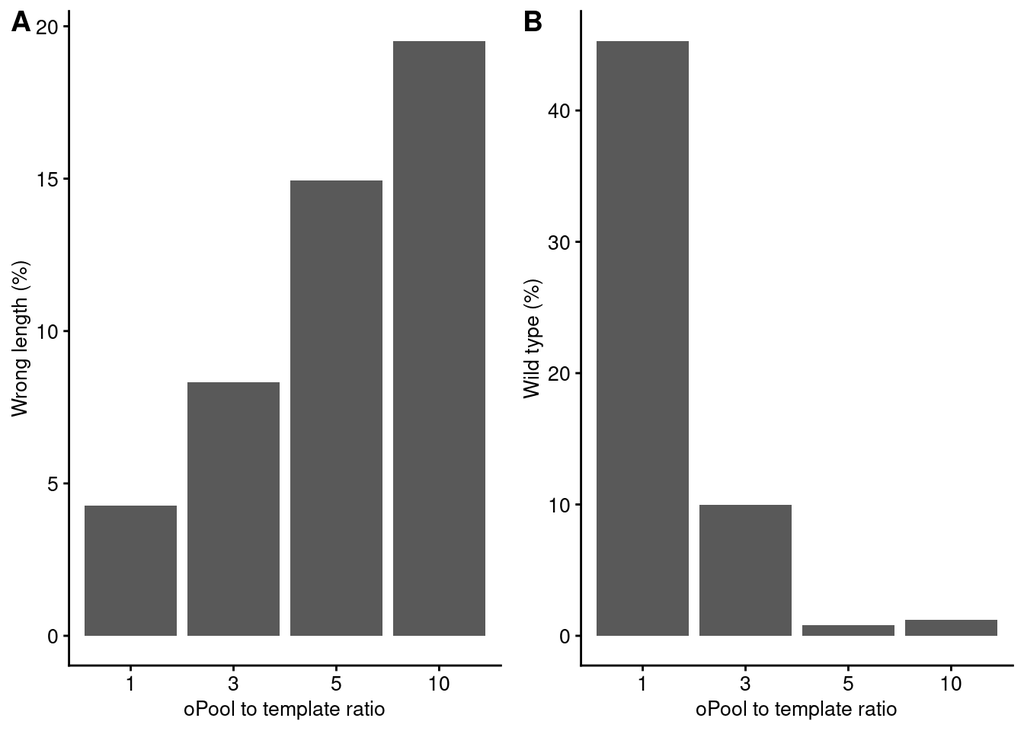

We studied the distribution of mutations per variant (Fig 2A)

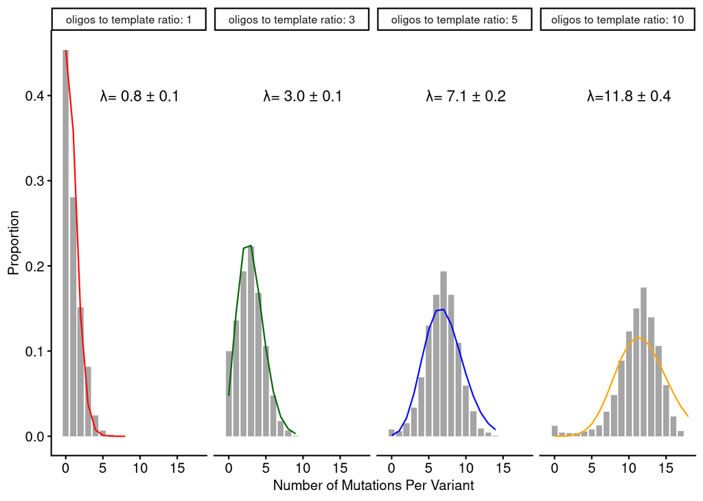

Statistical test to indicate that our experimental data actually follows a Poisson distribution

```
##
##  Pearson's Chi-squared test
##
## data:  mutations_distribution %>% filter(experiment == 1) %>% select(proportion,     predicted)
## X-squared = 0.040599, df = 8, p-value = 1
```

```
##
##  Pearson's Chi-squared test
##
## data:  mutations_distribution %>% filter(experiment == 3) %>% select(proportion,     predicted)
## X-squared = 0.023201, df = 9, p-value = 1
```

```
##
##  Pearson's Chi-squared test
##
## data:  mutations_distribution %>% filter(experiment == 5) %>% select(proportion,     predicted)
## X-squared = 0.050271, df = 14, p-value = 1
```

```
##
##  Pearson's Chi-squared test
##
## data:  mutations_distribution %>% filter(experiment == 10) %>% select(proportion,     predicted)
## X-squared = 0.12352, df = 19, p-value = 1
```

How many good-length variants are explored

```
## # A tibble: 4 × 2
##   experiment analysed_clones
##        <int>           <int>
## 1          1            5211
## 2          3            6330
## 3          5            8469
## 4         10            8314
```

How many non-wildtype, good-length variants are explored

```
## # A tibble: 4 × 2
##   experiment analysed_clones
##        <int>           <int>
## 1          1            2728
## 2          3            5223
## 3          5            7147
## 4         10            6609
```

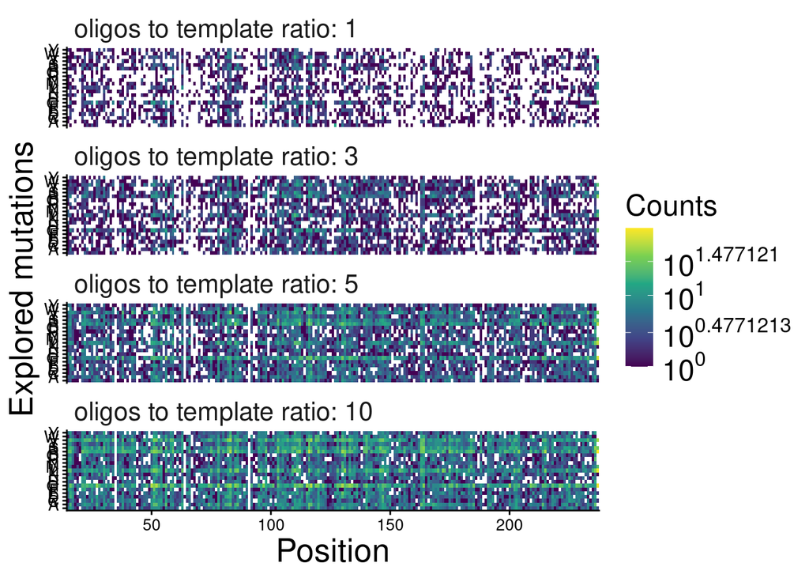

```
## # A tibble: 4 × 3
##   experiment total_mutations percentage_explored_mutation_from_all_possible
##        <int>           <int>                                          <dbl>
## 1          1            2112                                           47.4
## 2          3            2981                                           66.8
## 3          5            3772                                           84.6
## 4         10            4105                                           92.0
```

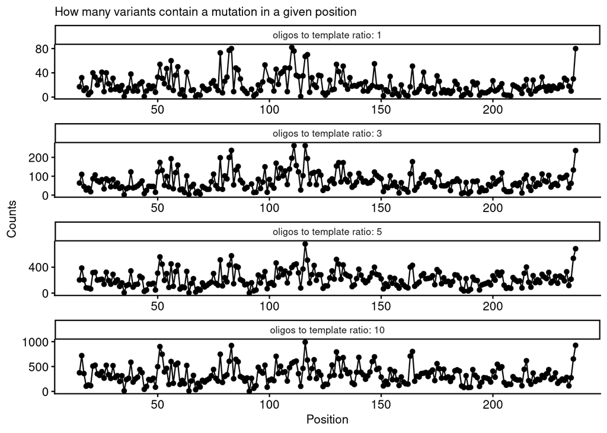

How many joint amino acid mutations are explored? This code takes a few minutes, so results are provided in data/ and uploaded in next code block.

```
## # A tibble: 4 × 2
##   experiment n_different_pairs
##        <int>             <int>
## 1          1              3068
## 2          3             24282
## 3          5            155031
## 4         10            382069
```

## 1.1 Biases in oligos efficiency

Mutations frequencies vs oligo

Check if distributions are normal by Shapito test

```
## # A tibble: 4 × 5
##   start_oligo `1`   `3`   `5`   `10`
##   <chr>       <chr> <chr> <chr> <chr>
## 1 A           ***   ***   ***   ***
## 2 C           *     N.S.  N.S.  N.S.
## 3 G           ***   *     N.S.  N.S.
## 4 T           ***   **    **    **
```

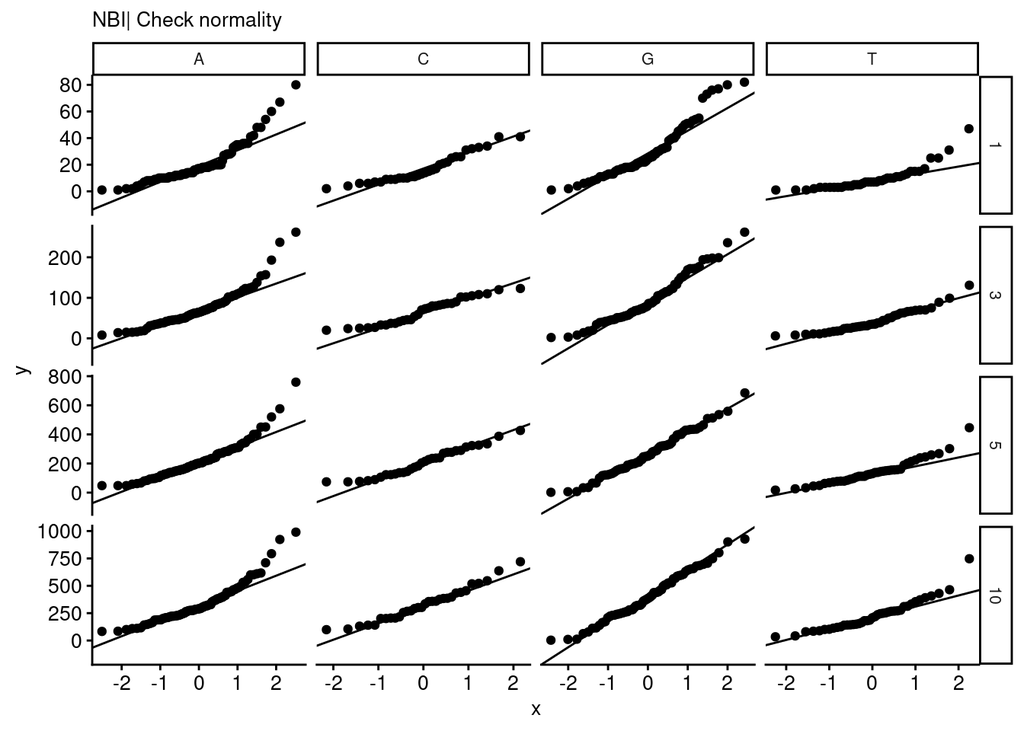

-> Not normal

Then use kruskal test to see if distributions are statistically different

```
## [1] 1
##
##  Kruskal-Wallis rank sum test
##
## data:  counts by start_oligo
## Kruskal-Wallis chi-squared = 51.247, df = 3, p-value = 4.334e-11
##
## [1] 3
##
##  Kruskal-Wallis rank sum test
##
## data:  counts by start_oligo
## Kruskal-Wallis chi-squared = 33.4, df = 3, p-value = 2.651e-07
##
## [1] 5
##
##  Kruskal-Wallis rank sum test
##
## data:  counts by start_oligo
## Kruskal-Wallis chi-squared = 27.411, df = 3, p-value = 4.827e-06
##
## [1] 10
##
##  Kruskal-Wallis rank sum test
##
## data:  counts by start_oligo
## Kruskal-Wallis chi-squared = 24.194, df = 3, p-value = 2.275e-05
```

As all p-values are smaller than 0.05, I move to dunn test statistical differences in all combinations

[output not shown]

Repeat for 3’ base: there is no significant differences

Shapiro test to check normality

```
## # A tibble: 4 × 5
##   end_oligo `1`   `3`   `5`   `10`
##   <chr>     <chr> <chr> <chr> <chr>
## 1 A         ***   ***   ***   ***
## 2 C         **    *     *     *
## 3 G         *     N.S.  N.S.  N.S.
## 4 T         ***   ***   ***   **
```

```
## [1] 1
##
##  Kruskal-Wallis rank sum test
##
## data:  counts by end_oligo
## Kruskal-Wallis chi-squared = 0.53642, df = 3, p-value = 0.9108
##
## [1] 3
##
##  Kruskal-Wallis rank sum test
##
## data:  counts by end_oligo
## Kruskal-Wallis chi-squared = 1.4495, df = 3, p-value = 0.694
##
## [1] 5
##
##  Kruskal-Wallis rank sum test
##
## data:  counts by end_oligo
## Kruskal-Wallis chi-squared = 0.72896, df = 3, p-value = 0.8664
##
## [1] 10
##
##  Kruskal-Wallis rank sum test
##
## data:  counts by end_oligo
## Kruskal-Wallis chi-squared = 0.22556, df = 3, p-value = 0.9734
```

DunnTest for 3’ end of oligos

```
##    Var1 Var2 pval experiment signif y_plot x_plot
## 1     A    C    1          1   N.S.   1831    1.5
## 2     A    G    1          1   N.S.   2753    2.0
## 3     C    G    1          1   N.S.   2439    2.5
## 4     A    T    1          1   N.S.   1449    2.5
## 5     C    T    1          1   N.S.   2978    3.0
## 6     G    T    1          1   N.S.    607    3.5
## 7     A    C    1          3   N.S.   1327    1.5
## 8     A    G    1          3   N.S.   2844    2.0
## 9     C    G    1          3   N.S.   1519    2.5
## 10    A    T    1          3   N.S.   1115    2.5
## 11    C    T    1          3   N.S.   2839    3.0
## 12    G    T    1          3   N.S.    636    3.5
## 13    A    C    1          5   N.S.   2459    1.5
## 14    A    G    1          5   N.S.   1024    2.0
## 15    C    G    1          5   N.S.    676    2.5
## 16    A    T    1          5   N.S.    526    2.5
## 17    C    T    1          5   N.S.   2201    3.0
## 18    G    T    1          5   N.S.   2739    3.5
## 19    A    C    1         10   N.S.   2719    1.5
## 20    A    G    1         10   N.S.   2511    2.0
## 21    C    G    1         10   N.S.   1863    2.5
## 22    A    T    1         10   N.S.   1050    2.5
## 23    C    T    1         10   N.S.   1232    3.0
## 24    G    T    1         10   N.S.   2424    3.5
```

They are all not significant

```
## Notch went outside hinges
## ℹ Do you want `notch = FALSE`?
```

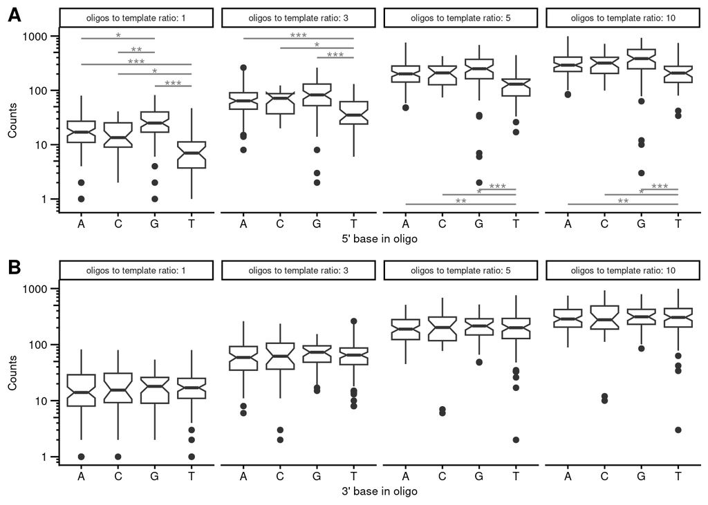

Figure 2C for main text

**Figure 2**

```
## Notch went outside hinges
## ℹ Do you want `notch = FALSE`?
```

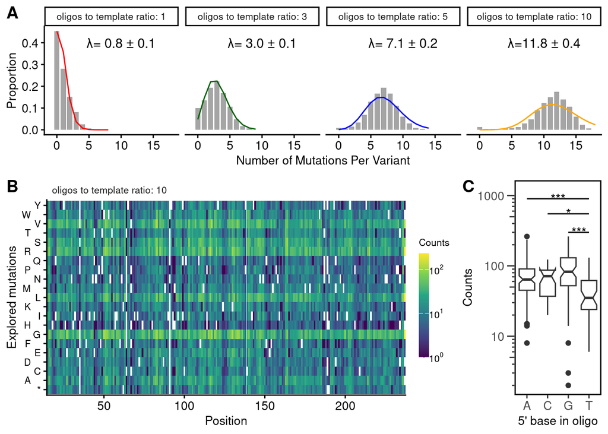

We also studied if there was dependency on the Tm of the oligos. We computed the Tm using NEB interface.

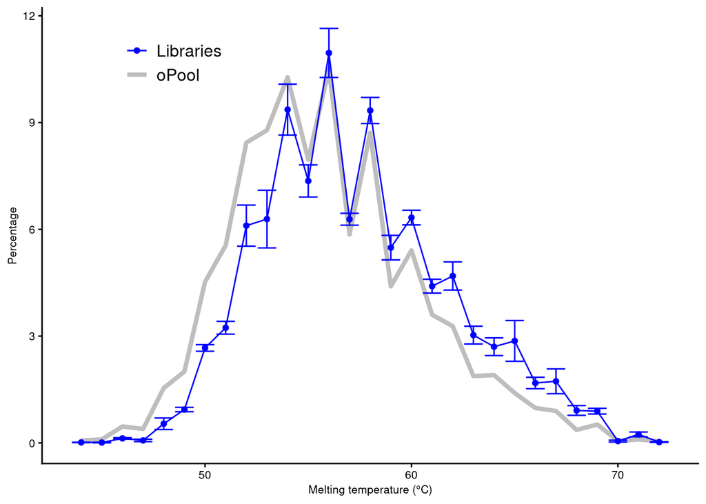

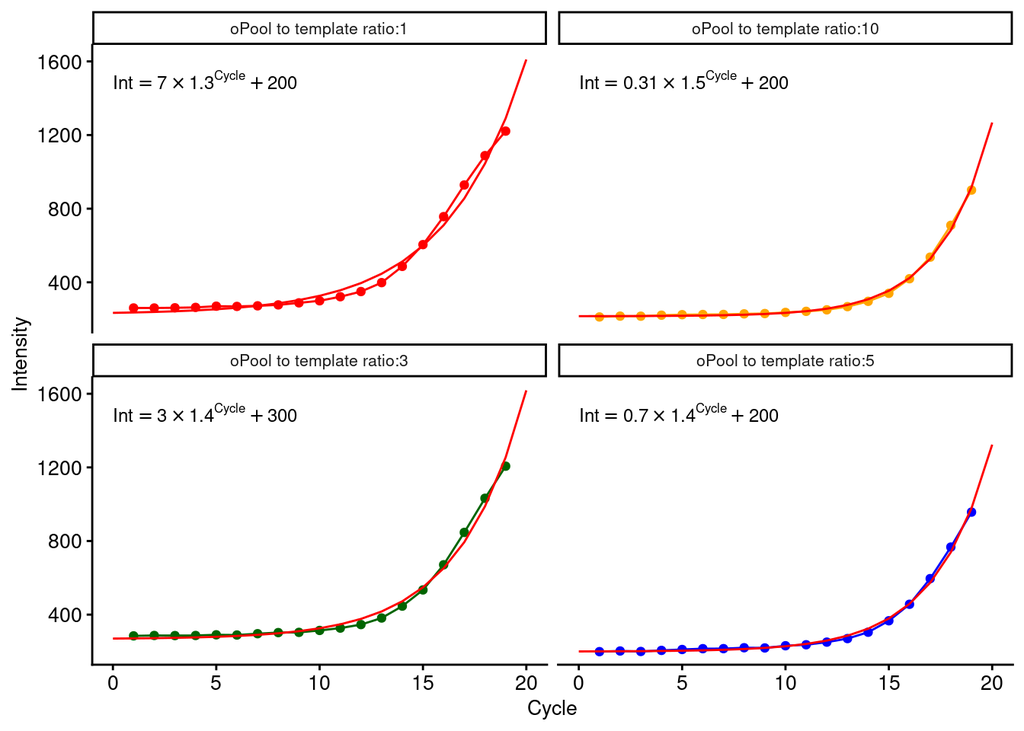

# 2 GFP

Reference sequences

Load data

Load oligo pool

How many reads per experiment

```
## # A tibble: 4 × 2
##   experiment                total_variants
##   <fct>                              <int>
## 1 λ-exonuclease degradation           3482
## 2 SPA + Beads purification            3499
## 3 SPA + Gel purification              1779
## 4 dsDNA                               4466
```

Distribution of number of mutations

Compute distribution of # mutations

Fit distributions by Poisson, but ignore wild types for the fitting as they are quiet a lot and will impair the convergence

```
## [1] "λ-exonuclease degradation 9.42" "SPA + Beads purification 9.52"
## [3] "SPA + Gel purification 9.94"    "dsDNA 11.01"
```

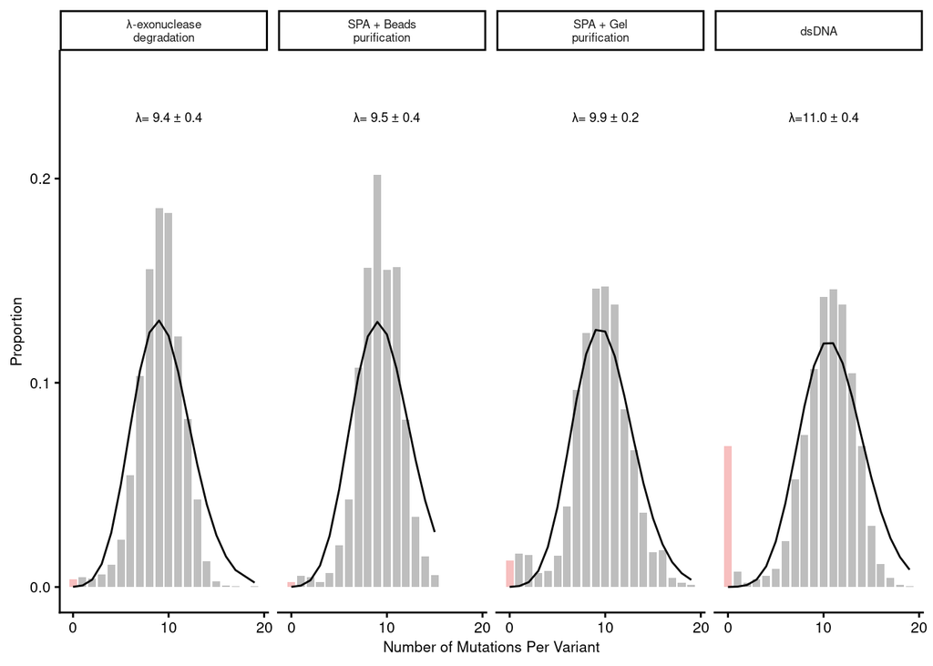

Look at results (pval<0.05 rejects poisson distribution)

```
##                  experiment       lam       std chisq_value pval_chisq
## 1 λ-exonuclease degradation  9.423999 0.3565589   0.3486835  1.0000000
## 2  SPA + Beads purification  9.524630 0.4453539   0.2654112  1.0000000
## 3    SPA + Gel purification  9.936882 0.2209559   4.0817718  0.9998757
## 4                     dsDNA 11.012719 0.3615967 285.9647188  0.0000000
```

I check that for dsDNA, I can recover it if I omit wild types

```
##
## dsDNA removing wild type. X2= 0.4155391 and p-value= 1
```

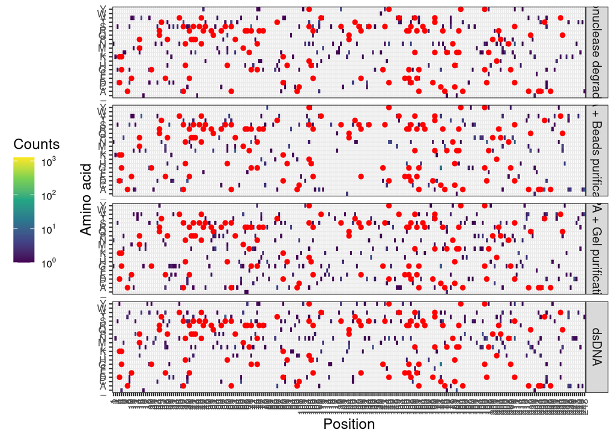

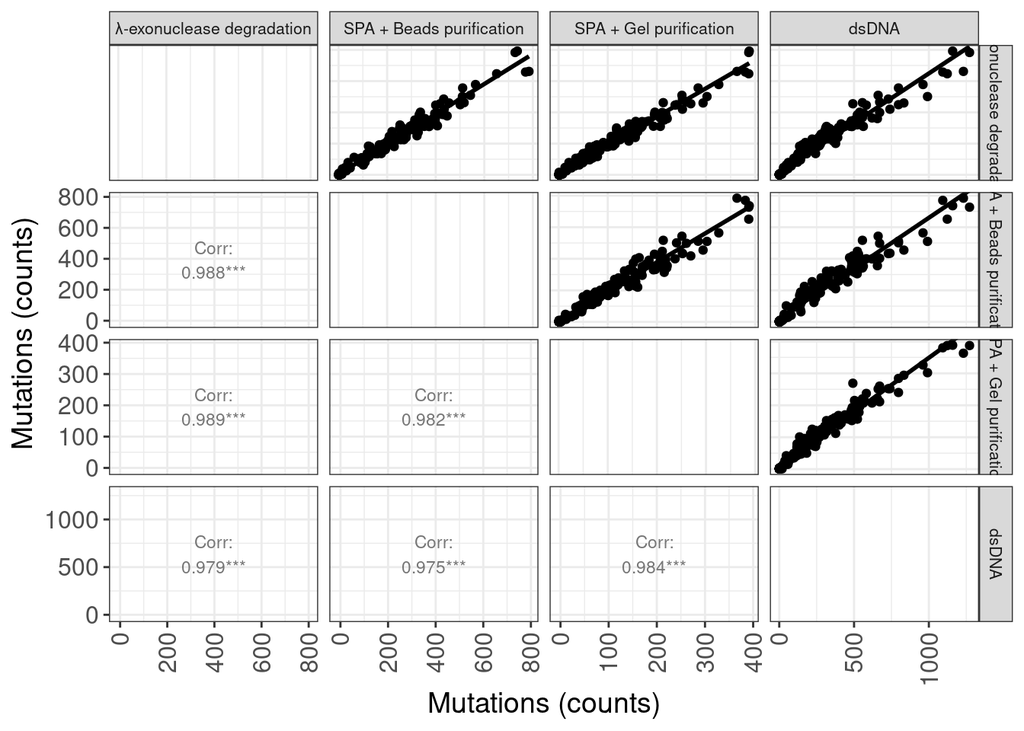

How many exact variants are repeated in the different samples?

```
## # A tibble: 4 × 2
##   in_how_many_samples how_many_variants
##                 <int>             <int>
## 1                   1              8679
## 2                   2               335
## 3                   3                13
## 4                   4                 1
```

## 2.1 Activity

[output not shown]

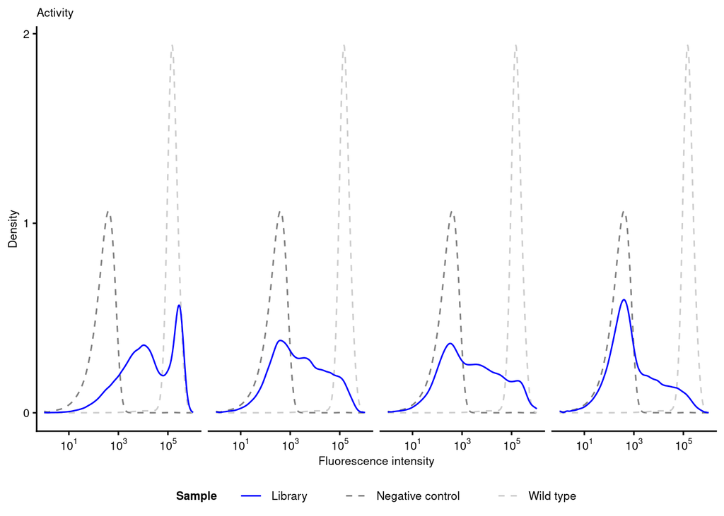

# 3 Bst polymerase

```
## # A tibble: 2 × 2
##   experiment       n_clones
##   <chr>               <int>
## 1 oPool Mix 5:1         805
## 2 oPool Single 5:1      142
```

```
## # A tibble: 2 × 2
##   experiment       n_different_variants
##   <chr>                           <int>
## 1 oPool Mix 5:1                     214
## 2 oPool Single 5:1                   40
```

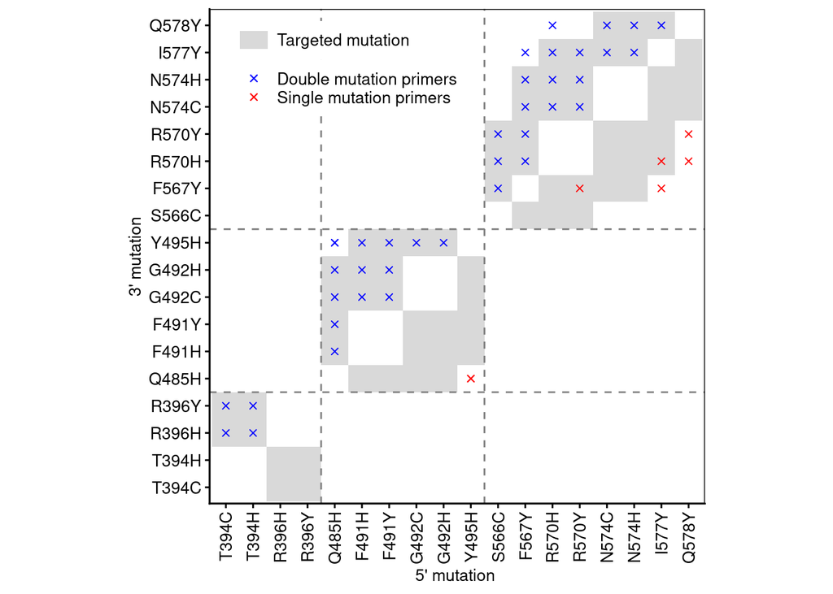

**Figure 3**

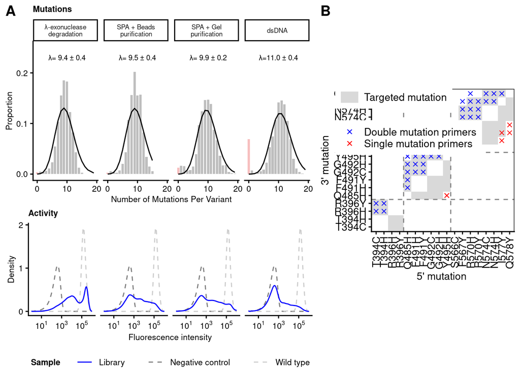

Variants with double mutants in the Single library

```
##         experiment   mutations nreads_consensus PlateID all_targeted dist
## 1 oPool Single 5:1 F567Y-I577Y               62   1 O20         TRUE  -10
## 2 oPool Single 5:1 F567Y-R570Y               69   1 H20         TRUE   -3
## 3 oPool Single 5:1 Q485H-Y495H               71    1 E1         TRUE  -10
## 4 oPool Single 5:1 Q485H-Y495H               60    1 L8         TRUE  -10
## 5 oPool Single 5:1 R570H-I577Y               84    1 E5         TRUE   -7
## 6 oPool Single 5:1 R570H-I577Y               76   1 H23         TRUE   -7
## 7 oPool Single 5:1 R570H-Q578Y               94    1 F7         TRUE   -8
## 8 oPool Single 5:1 R570Y-Q578Y               42   1 L24         TRUE   -8
```

```
##        Observed Not_observed
## Single        3           31
## Mix          34            0
```

```
##
##  Fisher's Exact Test for Count Data
##
## data:  fisher_mat
## p-value = 5.462e-16
## alternative hypothesis: true odds ratio is not equal to 1
## 95 percent confidence interval:
##  0.00000000 0.02042536
## sample estimates:
## odds ratio
##          0
```

What are the chances of getting the Single Mut. distribution by subsampling the Single+Double mut. results? Test by subsampling:

How many times we obtain less than 3 double mutants?  
None. So prob is less than 0.001

```
## # A tibble: 0 × 3
## # ℹ 3 variables: muttype <chr>, n_mutants <int>, run_subset_ID <int>
```